# tp2-sol

Ce TP nécessite un environnement contenant:

- Python (>= 3.6)
- scikit-learn (0.24.2)
- numpy (1.19) (vient automatiquement avec scikit-learn)
- matplotlib
- pandas
- jupyter
- ipykernel

Si vous n'avez pas un tel environnement, dans un invite de commandes Anaconda ou MiniConda, tapez:

conda create --name env_rl_tp python=3.6 scikit-learn=0.24.2 matplotlib pandas ipykernel jupyter

# TP2

L'objectif de ce TP est, dans un premier temps, de se familiariser avec la régression linéaire (RL) dans un cadre prédictif. Nous allons utiliser le jeu de données "Boston Houssing Prices" présenté en cours.

Dans un second temps, nous aborderons une des limites de la régression linéaire: la dimension i.e. ce qui se passe quand le nombre de variables $X_1, \dots, X_d$ devient très grand, ce qui nous amènera au second cours.

## Partie I

Utilisation de la RL-ridge pour la prédiction de prix de biens immobiliers à partir. Même jeu de données que pour TP#1

### Préliminaires

```python
from sklearn.datasets import load_boston
from sklearn.linear_model import LinearRegression, RidgeCV
from sklearn.metrics import r2_score, mean_squared_error
from sklearn.model_selection import cross_validate
import matplotlib.pyplot as plt
import numpy as np
from scipy.stats import describe as sp_describe
import pandas as pd
```

On importe le jeu de données "Boston Houssing Prices" avec Scikit-learn dans deux variables: X pour les mesures des variables prédictives et y pour celles de la variable cible.

```python
dataset = load_boston()
var_names = dataset.feature_names
X_df, y_df = pd.DataFrame(dataset.data, columns = var_names), pd.DataFrame(dataset.target, columns=['target'])
X, y = np.array(X_df), np.array(y_df) # copy in numpy.array format
n, d = X.shape
```

Rappel TP#1: Avant d'effectuer un apprentissage de modèle prédictif, il est FONDAMENTAL d'analyser les données en question (statistique descriptive). Il faut visualiser $x_{i1} \dots x_{id}$ indépendamment des $y_i$ (boxplot, histogramme), puis regarder quelques caractéristiques statistiques (moyennes, min, max, médiane, etc), ensuite regarder la relation en les observations de la cible $y_i$ et des prédicteurs. C'est cette analyse qui nous amène à postuler le modèle linénaire comme bon candidat prédictif.

Une partie de l'analyse peut être focalisée sur l'analyse de corrélation entre les prédicteurs.

```python
X_df.corr().style.background_gradient(cmap='coolwarm').set_precision(2)
```

|  | CRIM | ZN | INDUS | CHAS | NOX | RM | AGE | DIS | RAD | TAX | PTRATIO | B | LSTAT |
| --- | --- | --- | --- | --- | --- | --- | --- | --- | --- | --- | --- | --- | --- |
| CRIM | 1 | -0.2 | 0.41 | -0.056 | 0.42 | -0.22 | 0.35 | -0.38 | 0.63 | 0.58 | 0.29 | -0.39 | 0.46 |
| ZN | -0.2 | 1 | -0.53 | -0.043 | -0.52 | 0.31 | -0.57 | 0.66 | -0.31 | -0.31 | -0.39 | 0.18 | -0.41 |
| INDUS | 0.41 | -0.53 | 1 | 0.063 | 0.76 | -0.39 | 0.64 | -0.71 | 0.6 | 0.72 | 0.38 | -0.36 | 0.6 |
| CHAS | -0.056 | -0.043 | 0.063 | 1 | 0.091 | 0.091 | 0.087 | -0.099 | -0.0074 | -0.036 | -0.12 | 0.049 | -0.054 |
| NOX | 0.42 | -0.52 | 0.76 | 0.091 | 1 | -0.3 | 0.73 | -0.77 | 0.61 | 0.67 | 0.19 | -0.38 | 0.59 |
| RM | -0.22 | 0.31 | -0.39 | 0.091 | -0.3 | 1 | -0.24 | 0.21 | -0.21 | -0.29 | -0.36 | 0.13 | -0.61 |
| AGE | 0.35 | -0.57 | 0.64 | 0.087 | 0.73 | -0.24 | 1 | -0.75 | 0.46 | 0.51 | 0.26 | -0.27 | 0.6 |
| DIS | -0.38 | 0.66 | -0.71 | -0.099 | -0.77 | 0.21 | -0.75 | 1 | -0.49 | -0.53 | -0.23 | 0.29 | -0.5 |
| RAD | 0.63 | -0.31 | 0.6 | -0.0074 | 0.61 | -0.21 | 0.46 | -0.49 | 1 | 0.91 | 0.46 | -0.44 | 0.49 |
| TAX | 0.58 | -0.31 | 0.72 | -0.036 | 0.67 | -0.29 | 0.51 | -0.53 | 0.91 | 1 | 0.46 | -0.44 | 0.54 |
| PTRATIO | 0.29 | -0.39 | 0.38 | -0.12 | 0.19 | -0.36 | 0.26 | -0.23 | 0.46 | 0.46 | 1 | -0.18 | 0.37 |
| B | -0.39 | 0.18 | -0.36 | 0.049 | -0.38 | 0.13 | -0.27 | 0.29 | -0.44 | -0.44 | -0.18 | 1 | -0.37 |
| LSTAT | 0.46 | -0.41 | 0.6 | -0.054 | 0.59 | -0.61 | 0.6 | -0.5 | 0.49 | 0.54 | 0.37 | -0.37 | 1 |

La corrélation est une mesure statistique de "linéarité" entre deux variables, qui prend valeur entre -1 et 1. On voit qye TAX et RAD sont très corrélés, tout comme AGE et NOX.

### Apprentissage des paramètres $w_{1}, \dots, w_{d}$

#### Estimateur "brute"

On va estimer les paramtères du modèle en utilisant les opérateurs matriciels de NumPy, puis on utilisera et comperera les résultats avec un estimateur de Scikit-learn.

On reprend le code du TP#1.

1- Ecrire une fonction qui prédit la variable cible $y_{i}^{pred}$ à partir de paramtères et d'une observation $x_{i}$ donnés.

```python
def pred_y(x, beta):
    """prediction de y selon x, beta"""
    pred = x @ beta
    return pred
```

2- Ecrire une fonction qui prend en entrée:

- un ensemble d'observations de la variable cible $y_{1}, \dots y_{i}, \dots$
- les prédictions associées $y_{1}^{pred} = \sum_j w_{j} x_{1j}, \dots y_{i}^{pred} = \sum_{j} w_{j} x_{ij}, \dots$

et retourne en sortie l'erreur quadratique moyenne.

```python
def err_quad(y_obs, y_pred):
    """erreur quadratique moyenne"""
    n = len(y_obs)
    e_i = y_obs - y_pred
    err_quad = np.square(e_i)
    res = 0.5 * (1/n) * np.sum(err_quad)
    return res
```

3-1 Ecrire une fonction estime les paramètres $w_{1}, \dots, w_{d}$, à partir des observations $\{ y_i, x_i \}_{i \leq n}$ de façon à minimiser l'erreur quadratique moyenne.

```python
def learn_w(X, Y):
    """solution des moindres carrés linéaires ordinaires"""
    w_hat = np.linalg.inv(X.T @ X) @ X.T @ Y
    return w_hat
```

3-2 Ecrire une fonction qui estime les paramètres selon la régularisation ridge de paramètre $\lambda$.

```python
def learn_w_ridge(X, Y, lam=0.001):
    """solution ridge"""
    d = X.shape[1]
    w_hat = np.linalg.inv(X.T @ X + lam * np.identity(d)) @ X.T @ Y
    return w_hat
```

4- Ecrire une fonction qui séparer les observations du jeu de données aléatoirement en un ensemble d'entraînement et un ensemble de test.

```python
np.random.seed(3011)
def split_train_test(X, Y, ratio=0.7):
    """train/test split"""
    n = len(Y)
    n_tr = int(ratio * n)
    idx_train = np.random.randint(low=0, high=n-1, size=n_tr-1) # indices python commence à 0.
    idx_test = np.setdiff1d(ar1=np.arange(0, n-1), ar2=idx_train)
    idx_train, idx_test = list(idx_train), list(idx_test)
    Y_train, X_train = Y[idx_train], X[idx_train, :]
    Y_test, X_test = Y[idx_test], X[idx_test, :]
    # centrage des données:
    X_mean, y_mean = X_train.mean(axis=0), Y_train.mean()
    X_train -= X_mean
    X_test -= X_mean
    Y_train -= y_mean
    Y_test -= y_mean
    return X_train, X_test, Y_train, Y_test
```

5- Utiliser les fonctions précédentes pour:

- apprendre un modèle linéaire sur le jeu de données fourni,
- évaluer l'erreur de généralisation du modèle appris sur un jeu de données test (aussi "appelée erreur de test"),
- évaluer aussi l'erreur d'entraînement.

```python
# division aléatoire entraînement/test
X_tr, X_ts, y_tr, y_ts = split_train_test(X=X, Y=y, ratio=0.65)
```

```python
# apprentissge des paramètres sur l'ensemble d'entraînement
w_hat = learn_w(Y=y_tr, X=X_tr)
w_hat_ridge = learn_w_ridge(Y=y_tr, X=X_tr, lam=0.01)
# print("Paramètres du modèle: {}".format(w_hat))
```

```python
# evaluation de l'erreur de prédiction moyenne sur l'ensemble de test (erreur de généralisation)
y_pred_ts_ord = pred_y(X_ts, w_hat)
err_test_ord = err_quad(y_ts, y_pred_ts_ord)

# erreur de généralisation
y_pred_ts_ridge = pred_y(X_ts, w_hat_ridge)
err_test_ridge = err_quad(y_ts, y_pred_ts_ridge)

# évaluation des  erreurs d'entrainement
## avec les LR ordinaire
y_pred_tr_ord = pred_y(X_tr, w_hat)
err_train_ord = err_quad(y_tr, y_pred_tr_ord)

## avec la LR ridge
y_pred_tr_ridge = pred_y(X_tr, w_hat_ridge)
err_train_ridge = err_quad(y_tr, y_pred_tr_ridge)
```

```python
print("Erreur de test (LR ordinaire) = {}".format(err_test_ord))
print("Erreur d'entraînement = {}".format(err_train_ord))
```

```
Erreur de test (LR ordinaire) = 15.21348129393091
Erreur d'entraînement = 8.737981324711564
```

```python
print("Erreur de test (LR ridge) = {}".format(err_test_ridge))
print("Erreur d'entraînement = {}".format(err_train_ridge))
```

```
Erreur de test (LR ridge) = 15.22050787031441
Erreur d'entraînement = 8.73802048186616
```

Pour avoir une meilleure estimation de l'erreur de généralisation qu'avec une seule séparation entraînement/test, on répètre la procédure plusieurs fois puis on calcul la moyenne des erreurs de généralisations. Cette procédure s'appelle la "validation croisée".

6- Ecrire une fonction qui réalise la validation croisée, puis donnez une estimation de l'erreur de généralisation.

```python
def cv_rl(X, y, n_cv=10):
    err_cv = np.empty(shape=n_cv)
    for k in range(n_cv):
        X_tr, X_ts, y_tr, y_ts = split_train_test(X=X, Y=y, ratio=0.80)
        w_hat_k = learn_w(Y=y_tr, X=X_tr)
        pred = pred_y(X_ts, w_hat_k)
        err_cv[k] = err_quad(y_obs=y_ts, y_pred=pred)

    return err_cv
```

```python
def cv_rl_ridge(X, y, lam, n_cv=10):
    err_cv = np.empty(shape=n_cv)
    for k in range(n_cv):
        X_tr, X_ts, y_tr, y_ts = split_train_test(X=X, Y=y, ratio=0.80)
        w_hat_k = learn_w_ridge(Y=y_tr, X=X_tr, lam=lam)
        pred = pred_y(X_ts, w_hat_k)
        err_cv[k] = err_quad(y_obs=y_ts, y_pred=pred)

    return err_cv
```

```python
# np.random.seed(3011)
n_cv = 20
err_cv_ord = cv_rl(X=X, y=y, n_cv=n_cv)
err_cv_ridge = cv_rl_ridge(X=X, y=y, lam=0.01, n_cv=n_cv)
```

```python
print("RL ordinaire:")
print("Erreur de généralisation sur {} répétitions: {}".format(n_cv, err_cv_ord.mean()))
print("écart-type: {}".format(err_cv_ord.std()))
```

```
RL ordinaire:
Erreur de généralisation sur 20 répétitions: 12.705511133320194
écart-type: 2.137724088545249
```

```python
print("RL ridge:")
print("Erreur de généralisation sur {} répétitions: {}".format(n_cv, err_cv_ridge.mean()))
print("écart-type: {}".format(err_cv_ridge.std()))
```

```
RL ridge:
Erreur de généralisation sur 20 répétitions: 12.582316902535393
écart-type: 1.7026108275164977
```

## Partie II

#### Utilisation de Scitkit-learn

Scikit-learn permet de faire tout ce qu'on vient de coder de façon bien plus "propre" (i.e. une API).

```python
np.random.seed(3011)
# instatiation d'un objet LinearRegression
rl_ord = LinearRegression()
rl_ridge = RidgeCV(alphas=0.001)
# estimation
rl_ord.fit(X, y)
rl_ridge.fit(X, y)
```

```
RidgeCV(alphas=array(0.001))
```

### Choix du paramètre de régularissation $\lambda$

En pratique $\lambda$ est un paramètre que l'on ne peut pas apprendre, on le qualifie d'hyper-paramètre. Pour le sélectionner on se sert de l'erreur de généralisation:

- Spécifier une ensemble de valeurs candidates pour $\lambda_{1} \dots \lambda_{k} \dots \lambda_{M}$, Puis pour chacune de ces valeurs: (disons $\lambda_{k}$)
  - entraîner le modèle sur un ensemble de données d'entraînement avec $\lambda_{k}$, on obtient les paramètres appris $\hat{w}_{\lambda_{k}}$,
  - évaluer l'erreur de généralisation avec $\hat{w}_{\lambda_{k}}$ sur un ensemble de données de test,

Choisir la valeur de $\lambda$ testée qui donne la plus petite erreur de généralisation.

Tout cela se fait en quelques lignes avec Scikit-learn ! (L'hyper-paramètre est appelé 'alpha')

On compare à la régression linéaire ordinaire (comme au-dessus) mais en utilisant uniquement scikit-learn.

```python
from sklearn.model_selection import train_test_split, cross_val_score
```

```python
X_train, X_test, y_train, y_test = train_test_split(X, y, train_size=0.70, random_state=42)
```

```python
# valeur des paramètres de régul à tester
alphas_cand = np.logspace(-8, 1, num=25) # 10^-8, ..., 10^1
rl_ridge = RidgeCV(alphas_cand, store_cv_values=True)
rl_ridge.fit(X_train, y_train)
```

```
RidgeCV(alphas=array([1.00000000e-08, 2.37137371e-08, 5.62341325e-08, 1.33352143e-07,
       3.16227766e-07, 7.49894209e-07, 1.77827941e-06, 4.21696503e-06,
       1.00000000e-05, 2.37137371e-05, 5.62341325e-05, 1.33352143e-04,
       3.16227766e-04, 7.49894209e-04, 1.77827941e-03, 4.21696503e-03,
       1.00000000e-02, 2.37137371e-02, 5.62341325e-02, 1.33352143e-01,
       3.16227766e-01, 7.49894209e-01, 1.77827941e+00, 4.21696503e+00,
       1.00000000e+01]),
        store_cv_values=True)
```

```python
print("Meilleur hyper-paramètre de régularisation: ")
rl_ridge.alpha_
```

```
Meilleur hyper-paramètre de régularisation:
```

```
0.023713737056616554
```

Puis on prédit des données non-utilisées pour apprendre paramètres et hyper-paramètres.

#### Comparaison de l'erreur de prédiction à RL ordinaire

```python
rl_ord = LinearRegression()
rl_ord.fit(X=X_train, y=y_train)
```

```
LinearRegression()
```

```python
y_pred_ridge = rl_ridge.predict(X_test)
y_pred_ord = rl_ord.predict(X_test)
err_ridge = mean_squared_error(y_true=y_test, y_pred=y_pred_ridge)
err_ord = mean_squared_error(y_true=y_test, y_pred=y_pred_ord)
print("(Ridge) Erreur de généralisation finale {}".format(err_ridge))
print("(LR ordinaire) Erreur de généralisation finale {}".format(err_ord))
```

```
(Ridge) Erreur de généralisation finale 21.53351192849892
(LR ordinaire) Erreur de généralisation finale 21.517444231176995
```

Pour éviter "d'être tombé" sur une division entraînement/test non-représentative, en pratique il faut répéter ce procéssus plusieurs fois puis moyenner les erreurs de généralisation.

```python
rl_ridge = RidgeCV(alphas=0.023)
errors_val_ridge = cross_val_score(rl_ridge, X=X, y=y, cv=4, scoring="neg_mean_squared_error")
errors_val_ord = cross_val_score(rl_ord, X=X, y=y, cv=4, scoring="neg_mean_squared_error")
```

```python
print("(Ridge) erreur de généralisation {} +/- {}".format(-errors_val_ridge.mean(), errors_val_ridge.std()))
print("(RL ordinaire) erreur de généralisation {} +/- {}".format(-errors_val_ord.mean(), errors_val_ord.std()))
```

```
(Ridge) erreur de généralisation 42.287940212200866 +/- 19.573564727422397
(RL ordinaire) erreur de généralisation 42.36580749185289 +/- 19.602774901951697
```

Ridge fait légèrement mieux: il n'y qu'une voire deux variables prédictives corrélées donc forcément l'effet de la régularisation n'est pas énorme. Aussi, on est en basse dimension, n=506, d=13.

## Partie III

### Comparison de l'effet dimension LR-ordinaire/LR-ridge

On va comparer l'effet de la régularisation ridge sur les prédictions par rapport à une RL ordinaire, en présence de variables prédictives corrélées.

Regardons cela empiriquement sur des données artificielles.

```python
# nettoyage de l'espace des variables
%reset
```

```python
from sklearn.linear_model import LinearRegression, RidgeCV
from sklearn.datasets import make_regression
from sklearn.metrics import r2_score, mean_squared_error
from sklearn.model_selection import cross_val_score
import numpy as np
from matplotlib import pyplot as plt
```

```python
n = 200
d = 400
d_util = 20
X, y, w_true = make_regression(n_samples=n, n_features=d, n_informative=d_util, effective_rank=100, coef=True, random_state=3012)
idx_util = list(np.where(w_true != 0.0)[0])
idx_nonutil = list(np.where(w_true == 0.0)[0])
```

```python
err_ridge_d = np.empty(d)
std_ridge_d = np.empty(d)
alphas_cand = np.logspace(-8, 1, num=30)

err_ord_d = np.empty(d)
std_ord_d = np.empty(d)

for j in range(d):
    rl_ridge = RidgeCV(alphas_cand)
    rl_ord = LinearRegression()
    if j < d_util:
        # erreur de généralisation du modèle appris avec des variables utiles pour prédire y
        scores_rl_ridge = cross_val_score(rl_ridge, X[:, idx_util[:(j+1)]], y,
                                scoring="neg_mean_squared_error", cv=5)
        scores_rl_ord = cross_val_score(rl_ord, X[:, idx_util[:(j+1)]], y,
                        scoring="neg_mean_squared_error", cv=5)
    else:
        # erreur de généralisation du modèle appris avec toutes les variables utiles
        # et d'autes inutiles pour prédire y
        scores_rl_ridge = cross_val_score(rl_ridge, X[:, idx_util + idx_nonutil[:(j+1-d_util)]], y,
                                scoring="neg_mean_squared_error", cv=5)
        scores_rl_ord = cross_val_score(rl_ord, X[:, idx_util + idx_nonutil[:(j+1-d_util)]], y,
                                scoring="neg_mean_squared_error", cv=5)

    err_ridge_d[j] = -scores_rl_ridge.mean()
    std_ridge_d[j] = scores_rl_ridge.std()

    err_ord_d[j] = -scores_rl_ord.mean()
    std_ord_d[j] = scores_rl_ord.std()
```

```python
plt.rcParams['figure.dpi'] = 150
```

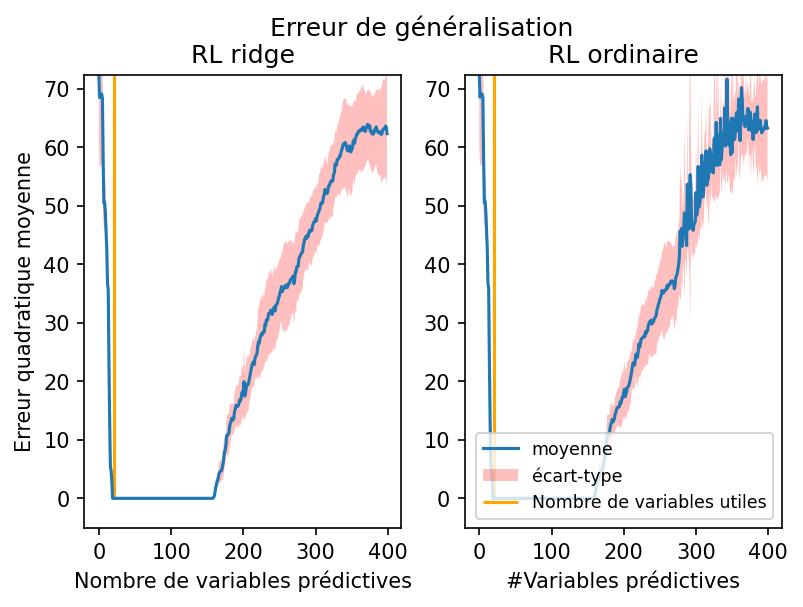

```python
# plot for ridge
plt.subplot(1,2,1)
plt.plot(np.arange(0, d), err_ridge_d)
plt.fill_between(np.arange(0, d),
    err_ridge_d + 1*std_ridge_d,
    err_ridge_d - 1*std_ridge_d,
    facecolor='red', alpha=0.25, label="écart-type err_quad")

plt.vlines(x=d_util+1, ymin=err_ridge_d.min(), ymax=err_ridge_d.max(),
    colors='orange', label="Nombre de variables utiles")

plt.ylim(ymin=err_ord_d.min()-5, ymax=err_ord_d.max())
plt.xlabel("Nombre de variables prédictives")
plt.ylabel("Erreur quadratique moyenne")
plt.title('RL ridge')

# plot for RL ordinaire
plt.subplot(1,2,2)
plt.plot(np.arange(0, d), err_ord_d, label="moyenne")
plt.fill_between(np.arange(0, d),
    err_ord_d + 1*std_ord_d,
    err_ord_d - 1*std_ord_d,
    facecolor='red', alpha=0.25, label="écart-type")

plt.vlines(x=d_util+1, ymin=err_ord_d.min(), ymax=err_ord_d.max(),
    colors='orange', label="Nombre de variables utiles")

plt.ylim(ymin=err_ord_d.min()-5, ymax=err_ord_d.max())
plt.xlabel("#Variables prédictives")
plt.title('RL ordinaire')
plt.legend(loc="lower right", fontsize='small', )

plt.suptitle('Erreur de généralisation')

plt.show()
```

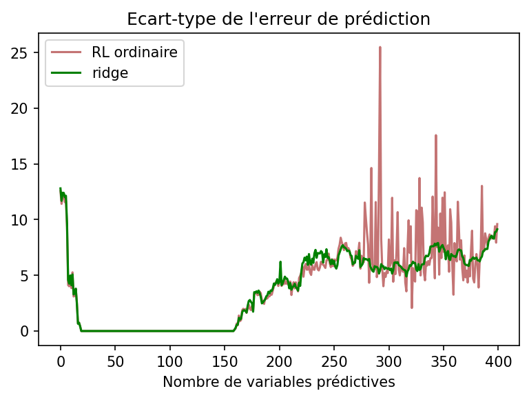

```python
plt.plot(np.arange(0, d), std_ord_d, label='RL ordinaire', color='brown', alpha=0.65)
plt.plot(np.arange(0, d), std_ridge_d, label='ridge', color='green')

plt.xlabel('Nombre de variables prédictives')
plt.title("Ecart-type de l'erreur de prédiction")
plt.legend()
plt.show()
```